# M2RClust Package Demonstration

KMeansClusterer for Variable Clustering

2025-11-19

# Introduction

Ce notebook présente les fonctionnalités principales du package **M2RClust**, notamment l’algorithme **KMeansClusterer** pour le clustering de variables (et non d’observations).

L’algorithme regroupe les variables en clusters en maximisant l’homogénéité intra-cluster, mesurée par la proportion de variance expliquée par la première composante principale de chaque cluster.

```r
# Charger le package
library(M2RClust)

# Packages additionnels pour la démonstration
library(ggplot2)
library(knitr)

# Configuration globale
set.seed(42)
```

# 1. Préparation des Données

Nous utilisons le dataset **mtcars** qui contient 11 variables quantitatives sur 32 modèles de voitures.

```r
# Charger les données
data(mtcars)

# Aperçu des données
kable(head(mtcars), caption = "Aperçu du dataset mtcars")
```

Aperçu du dataset mtcars

|  | mpg | cyl | disp | hp | drat | wt | qsec | vs | am | gear | carb |
| --- | --- | --- | --- | --- | --- | --- | --- | --- | --- | --- | --- |
| Mazda RX4 | 21.0 | 6 | 160 | 110 | 3.90 | 2.620 | 16.46 | 0 | 1 | 4 | 4 |
| Mazda RX4 Wag | 21.0 | 6 | 160 | 110 | 3.90 | 2.875 | 17.02 | 0 | 1 | 4 | 4 |
| Datsun 710 | 22.8 | 4 | 108 | 93 | 3.85 | 2.320 | 18.61 | 1 | 1 | 4 | 1 |
| Hornet 4 Drive | 21.4 | 6 | 258 | 110 | 3.08 | 3.215 | 19.44 | 1 | 0 | 3 | 1 |
| Hornet Sportabout | 18.7 | 8 | 360 | 175 | 3.15 | 3.440 | 17.02 | 0 | 0 | 3 | 2 |
| Valiant | 18.1 | 6 | 225 | 105 | 2.76 | 3.460 | 20.22 | 1 | 0 | 3 | 1 |

```r
# Dimensions
cat("Dimensions:", nrow(mtcars), "observations x", ncol(mtcars), "variables\n")
```

```
Dimensions: 32 observations x 11 variables
```

```r
# Vérifier que toutes les variables sont numériques
cat("\nTypes de variables:\n")
```

```
Types de variables:
```

```r
sapply(mtcars, class)
```

```
      mpg       cyl      disp        hp      drat        wt      qsec
"numeric" "numeric" "numeric" "numeric" "numeric" "numeric" "numeric"
       vs        am      gear      carb
"numeric" "numeric" "numeric" "numeric"
```

# 2. Initialisation du Clusterer

Nous créons une instance de `KMeansClusterer` avec 3 clusters.

```r
# Créer le clusterer
clusterer <- KMeansClusterer$new(
  data = mtcars,
  n_clusters = 3,
  standardize = TRUE,  # Standardiser les données (recommandé)
  max_iter = 100,
  seed = 42,
  n_init = 10,  # Nombre maximum d'initialisations
  init_method = "homogeneity++"  # Méthode d'initialisation intelligente
)

# Afficher les informations de base
print(clusterer)
```

```
Variable Clusterer (not fitted)
  Number of clusters: 3
  Number of variables: 11
  Standardize: YES
  n_init: 10
```

# 3. Ajustement du Modèle

Lançons l’algorithme de clustering.

```r
# Ajuster le modèle
clusterer$fit()

# Afficher les résultats
print(clusterer)
```

```
Variable Clusterer
  3 clusters (sizes: 5, 3, 3)
  Convergence after 2 iterations (init: homogeneity++, runs=4/10 - early stop)
  Global homogeneity: 0.822

Variable assignments:
```

| variable | cluster |
| --- | --- |
| mpg | 1 |
| cyl | 1 |
| disp | 1 |
| hp | 2 |
| drat | 3 |
| wt | 1 |
| qsec | 2 |
| vs | 1 |
| am | 3 |
| gear | 3 |

[output cut: 1 more lines]

# 4. Résumé Détaillé

```r
# Résumé complet avec toutes les métriques
clusterer$summary()
```

```
=================================================
Variable Clustering
=================================================

Configuration:
  - Number of clusters: 3
  - Number of variables: 11
  - Number of observations: 32
  - Standardize: YES
  - Initialization method: homogeneity++
  - Initialization runs: 4 / 10 (early stopped)
  - Iterations (best run): 2 / 100
  - Tolerance: 1.00e-04

Clustering Quality (Homogeneity Criterion):
  - Global homogeneity: 0.822
  - Interpretation: Proportion of variance explained by PC1 within clusters
  - Range: [0, 1] where 1 = perfect homogeneity

Cluster Sizes:
  Cluster 1: 5 variables
  Cluster 2: 3 variables
  Cluster 3: 3 variables

Within-Cluster Homogeneity:
  Cluster 1: 0.833 (n=5 vars)
    PC1 explains 83.3% of cluster variance
  Cluster 2: 0.803 (n=3 vars)
    PC1 explains 80.3% of cluster variance
  Cluster 3: 0.824 (n=3 vars)
    PC1 explains 82.4% of cluster variance

=================================================
```

# 5. Extraction des Résultats

```r
# Obtenir les résultats sous forme de dataframe
results <- clusterer$get_results()
kable(results, caption = "Assignations des variables aux clusters")
```

Assignations des variables aux clusters

| variable | cluster |
| --- | --- |
| mpg | 1 |
| cyl | 1 |
| disp | 1 |
| hp | 2 |
| drat | 3 |
| wt | 1 |
| qsec | 2 |
| vs | 1 |
| am | 3 |
| gear | 3 |
| carb | 2 |

```r
# Statistiques par cluster
cat("\n=== Statistiques par Cluster ===\n")
```

```
=== Statistiques par Cluster ===
```

```r
for (k in 1:3) {
  vars_in_cluster <- results$variable[results$cluster == k]
  cat("\nCluster", k, ":", length(vars_in_cluster), "variables\n")
  cat("Variables:", paste(vars_in_cluster, collapse = ", "), "\n")
}
```

```
Cluster 1 : 5 variables
Variables: mpg, cyl, disp, wt, vs

Cluster 2 : 3 variables
Variables: hp, qsec, carb

Cluster 3 : 3 variables
Variables: drat, am, gear
```

```r
# Homogénéité globale
cat("\n=== Homogénéité Globale ===\n")
```

```
=== Homogénéité Globale ===
```

```r
cat("Score:", round(clusterer$get_homogeneity(), 4), "\n")
```

```
Score: 0.8225
```

```r
# Homogénéité par cluster
cat("\n=== Homogénéité par Cluster ===\n")
```

```
=== Homogénéité par Cluster ===
```

```r
homogeneities <- clusterer$get_cluster_homogeneity()
for (k in 1:3) {
  cat("Cluster", k, ":", round(homogeneities[k], 4), "\n")
}
```

```
Cluster 1 : 0.833
Cluster 2 : 0.8034
Cluster 3 : 0.8239
```

# 6. Visualisations

## 6.1 Clustering en 2D (Espace PCA)

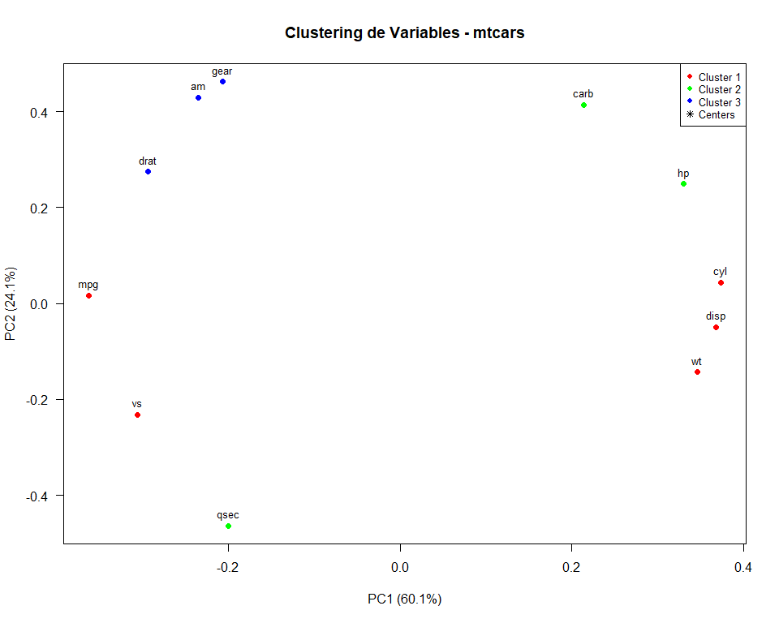

```r
# Visualisation principale dans l'espace des 2 premières composantes principales
plot_clustering_2d(
  clusterer,
  main = "Clustering de Variables - mtcars",
  show_centers = TRUE,
  show_labels = TRUE
)
```

## 6.2 Heatmap des Corrélations

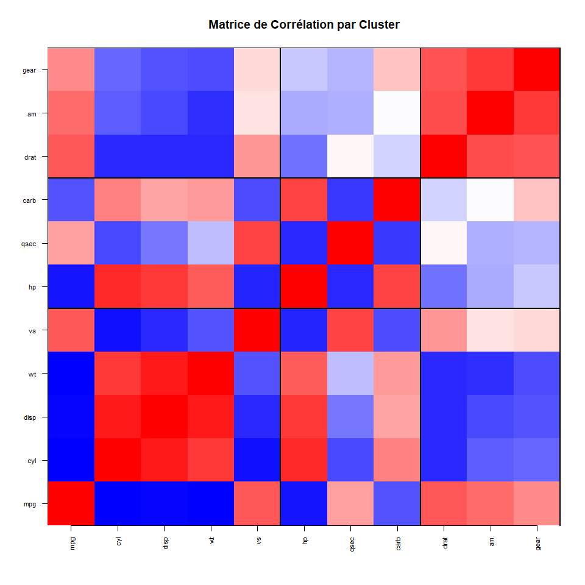

```r
# Heatmap des corrélations regroupées par cluster
plot_correlation_heatmap(
  clusterer,
  main = "Matrice de Corrélation par Cluster",
  reorder = TRUE
)
```

## 6.3 Réseau de Corrélations

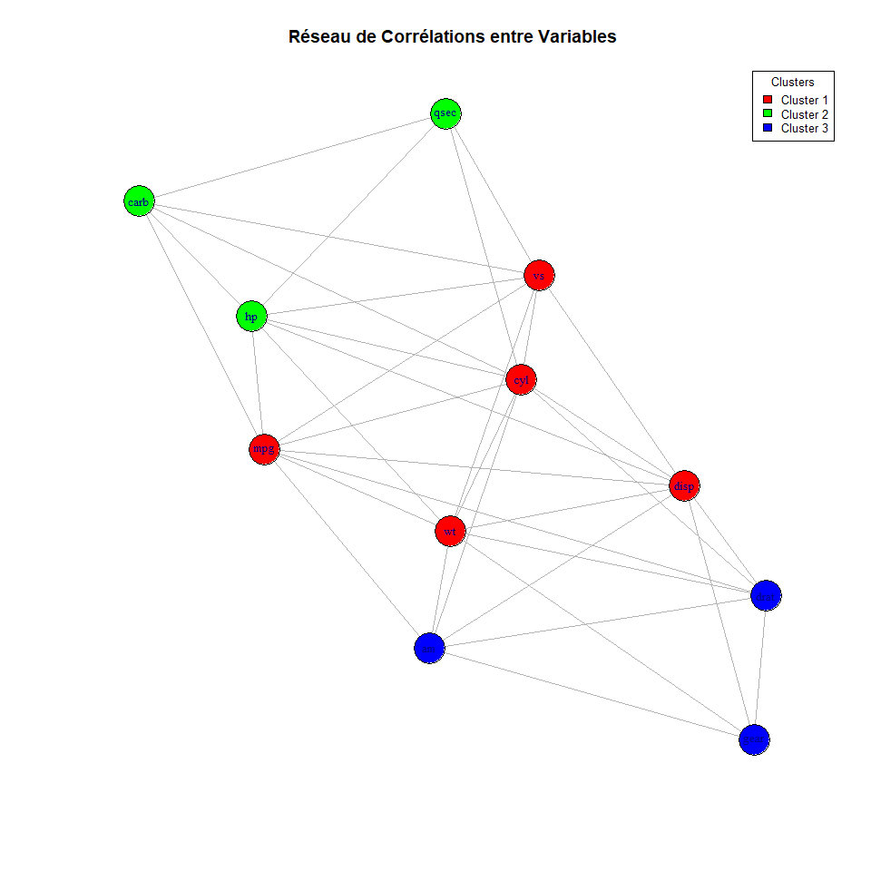

```r
# Graphe de réseau des corrélations
plot_network_graph(
  clusterer,
  threshold = 0.5,  # Seuil de corrélation
  main = "Réseau de Corrélations entre Variables",
  layout = "fruchterman.reingold"
)
```

## 6.4 Qualité des Clusters

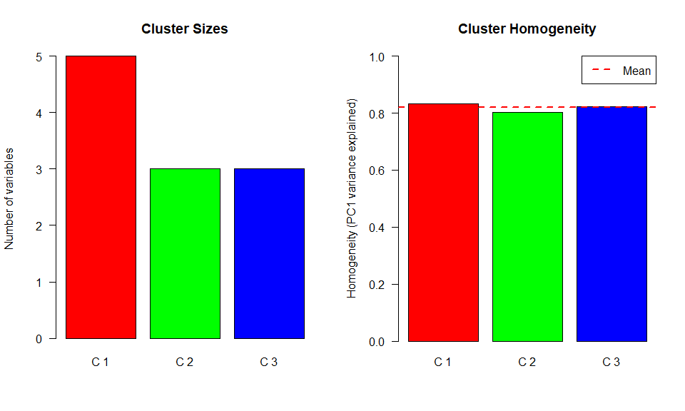

```r
# Métriques de qualité des clusters
metrics <- plot_cluster_quality(
  clusterer,
  main = "Métriques de Qualité des Clusters"
)
```

```r
# Afficher les métriques
cat("\n=== Tailles des Clusters ===\n")
```

```
=== Tailles des Clusters ===
```

```r
print(metrics$sizes)
```

```
[1] 5 3 3
```

```r
cat("\n=== Homogénéité des Clusters ===\n")
```

```
=== Homogénéité des Clusters ===
```

```r
print(metrics$homogeneity)
```

```
[1] 0.8330412 0.8034044 0.8239103
```

## 6.5 Radar Chart des Profils

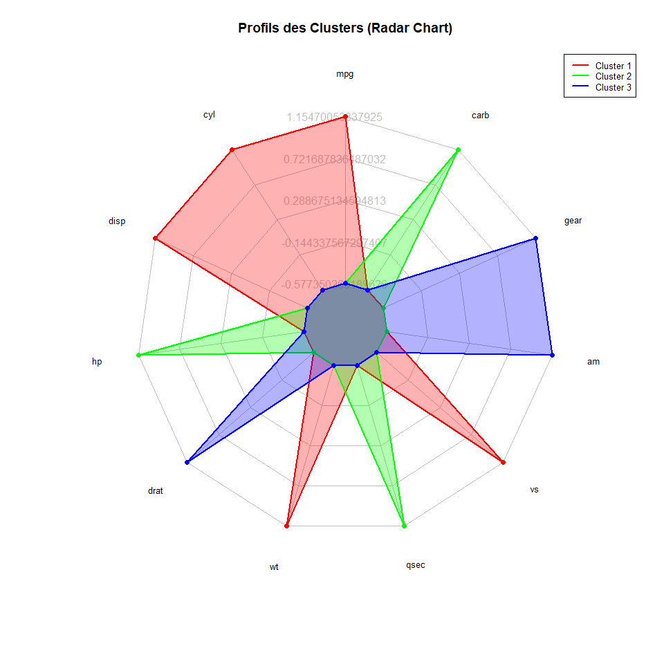

```r
# Diagramme radar des profils de clusters
plot_radar_chart(
  clusterer,
  main = "Profils des Clusters (Radar Chart)",
  standardize = TRUE
)
```

## 6.6 Contributions des Variables

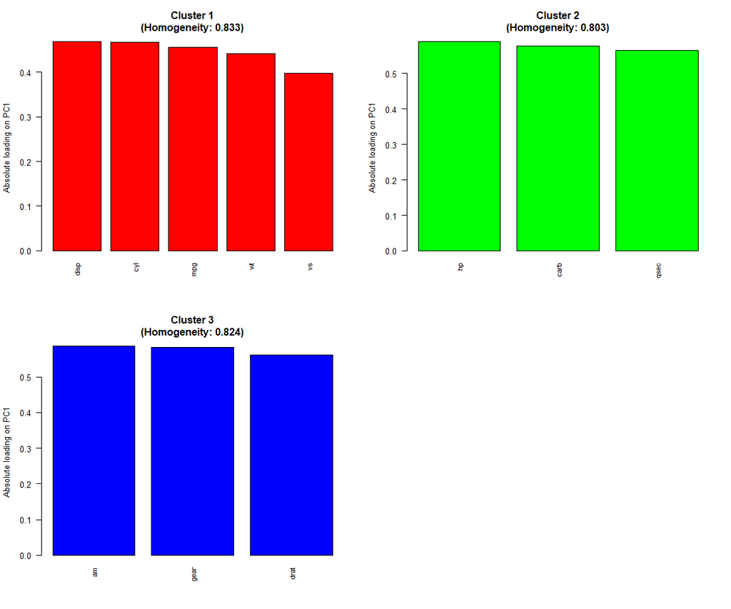

```r
# Contributions des variables à chaque cluster
plot_variable_contributions(
  clusterer,
  cluster_id = NULL,  # NULL = tous les clusters
  top_n = 5,  # Top 5 variables par cluster
  main = "Top 5 Variables Contributives par Cluster"
)
```

## 6.7 Scree Plots par Cluster

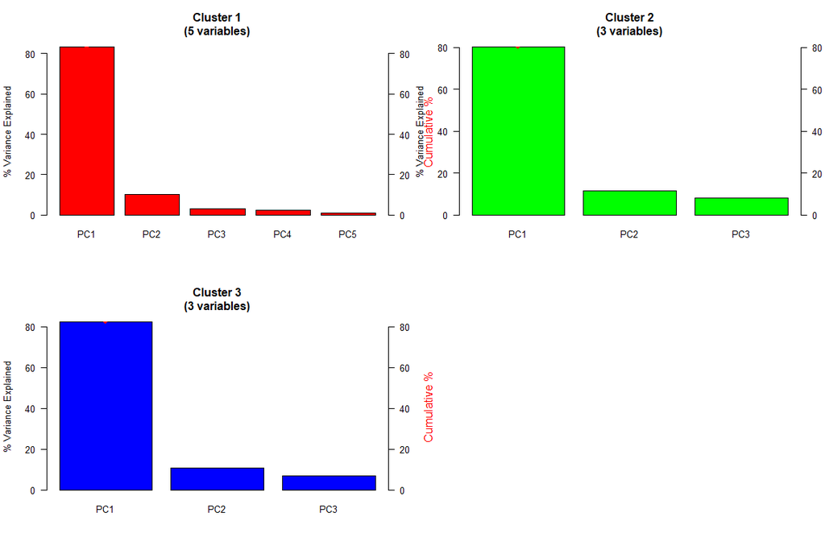

```r
# Variance expliquée par composante principale dans chaque cluster
plot_scree_by_cluster(
  clusterer,
  main = "Variance Expliquée par Cluster"
)
```

# 7. Prédiction sur Nouvelles Variables

Nous pouvons projeter de nouvelles variables (supplémentaires) dans l’espace de clustering existant.

```r
# Créer des variables supplémentaires (corrélées aux variables existantes)
# Exemple: nouvelles combinaisons linéaires
supp_data <- data.frame(
  hp_wt_ratio = mtcars$hp / mtcars$wt,
  disp_cyl_ratio = mtcars$disp / mtcars$cyl
)

cat("Variables supplémentaires:\n")
```

```
Variables supplémentaires:
```

```r
kable(head(supp_data), caption = "Aperçu des variables supplémentaires")
```

Aperçu des variables supplémentaires

| hp_wt_ratio | disp_cyl_ratio |
| --- | --- |
| 41.98473 | 26.66667 |
| 38.26087 | 26.66667 |
| 40.08621 | 27.00000 |
| 34.21462 | 43.00000 |
| 50.87209 | 45.00000 |
| 30.34682 | 37.50000 |

```r
# Prédire les clusters pour ces nouvelles variables
predictions <- clusterer$predict(supp_data, return_scores = TRUE)
kable(predictions, caption = "Prédictions pour les variables supplémentaires")
```

Prédictions pour les variables supplémentaires

| variable | cluster | score_1 | score_2 | score_3 |
| --- | --- | --- | --- | --- |
| hp_wt_ratio | 2 | 0.1244615 | 0.6648096 | 0.0386897 |
| disp_cyl_ratio | 1 | 0.7349749 | 0.1914402 | 0.4624763 |

## 7.1 Visualisation avec Variables Supplémentaires

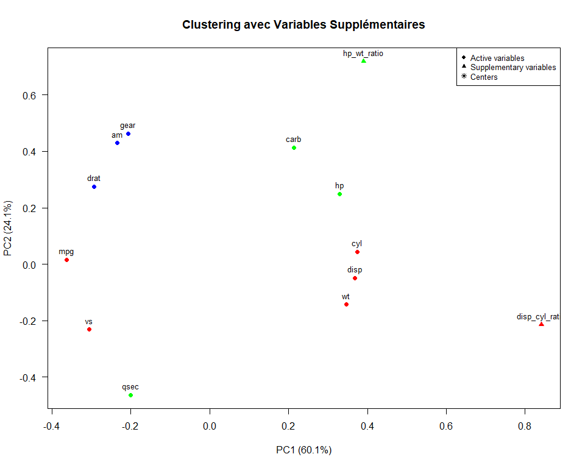

```r
# Visualiser avec les variables supplémentaires
plot_clustering_with_supp(
  clusterer,
  main = "Clustering avec Variables Supplémentaires",
  show_centers = TRUE,
  show_labels = TRUE
)
```

# 8. Sélection Automatique du Nombre de Clusters

Le package fournit plusieurs méthodes pour déterminer le nombre optimal de clusters.

## 8.1 Méthode du Coude (Elbow)

```
Calculating elbow method...
  K = 2...
  K = 3...
  K = 4...
  K = 5...
  K = 6...
  K = 7...
  K = 8...

K suggested by elbow method: 4
```

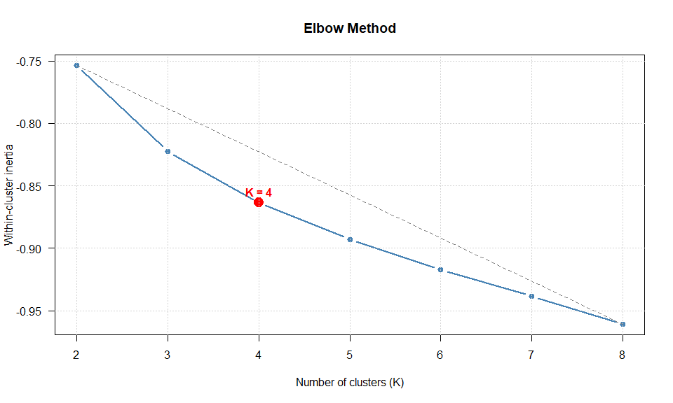

```r
elbow_results <- elbow_method(
  KMeansClusterer,
  mtcars,
  k_range = 2:8,
  plot = TRUE,
  standardize = TRUE,
  seed = 42
)
```

```r
cat("\nK suggéré par la méthode du coude:", elbow_results$suggested_k, "\n")
```

```
K suggéré par la méthode du coude: 4
```

## 8.2 Méthode de la Silhouette

```
Calculating silhouette method...
  K = 2...
  K = 3...
  K = 4...
  K = 5...
  K = 6...
  K = 7...
  K = 8...

Suggested K by silhouette method: 2
Silhouette coefficient: 0.000
```

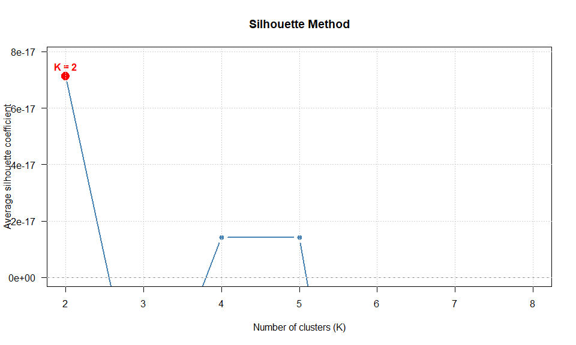

```r
silhouette_results <- silhouette_method(
  KMeansClusterer,
  mtcars,
  k_range = 2:8,
  plot = TRUE,
  standardize = TRUE,
  seed = 42
)
```

```r
cat("\nK suggéré par la méthode silhouette:", silhouette_results$suggested_k, "\n")
```

```
K suggéré par la méthode silhouette: 2
```

```r
cat("Score silhouette:", round(silhouette_results$silhouette_scores[silhouette_results$suggested_k - 1], 4), "\n")
```

```
Score silhouette: 0
```

## 8.3 Indice de Calinski-Harabasz

```
Calculating Calinski-Harabasz index...
  K = 2...
  K = 3...
  K = 4...
  K = 5...
  K = 6...
  K = 7...
  K = 8...

K suggested by Calinski-Harabasz: 2
Calinski-Harabasz score: 0.00
```

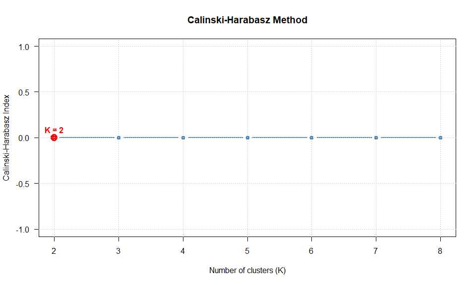

```r
ch_results <- calinski_harabasz_method(
  KMeansClusterer,
  mtcars,
  k_range = 2:8,
  plot = TRUE,
  standardize = TRUE,
  seed = 42
)
```

```r
cat("\nK suggéré par Calinski-Harabasz:", ch_results$suggested_k, "\n")
```

```
K suggéré par Calinski-Harabasz: 2
```

```r
cat("Score CH:", round(ch_results$ch_scores[ch_results$suggested_k - 1], 2), "\n")
```

```
Score CH: 0
```

## 8.4 Indice de Davies-Bouldin

```
Calculating Davies-Bouldin index...
  K = 2...
  K = 3...
  K = 4...
  K = 5...
  K = 6...
  K = 7...
  K = 8...

Suggested K by Davies-Bouldin: 5
DB Score: 0.615
```

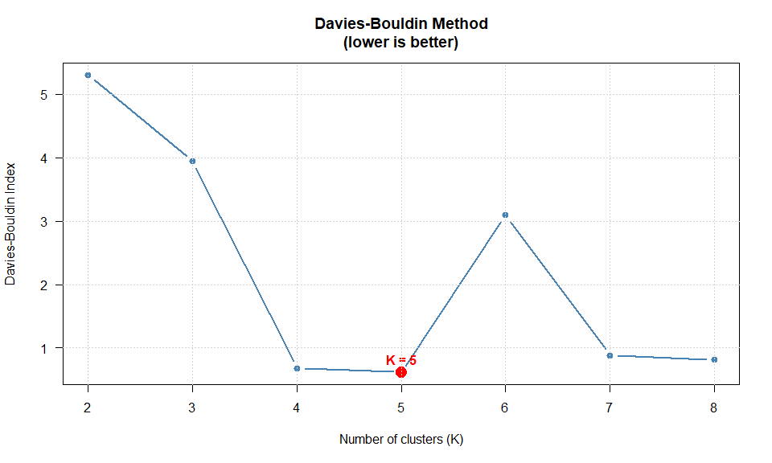

```r
db_results <- davies_bouldin_method(
  KMeansClusterer,
  mtcars,
  k_range = 2:8,
  plot = TRUE,
  standardize = TRUE,
  seed = 42
)
```

```r
cat("\nK suggéré par Davies-Bouldin:", db_results$suggested_k, "\n")
```

```
K suggéré par Davies-Bouldin: 5
```

```r
cat("Score DB:", round(db_results$db_scores[db_results$suggested_k - 1], 4), "\n")
```

```
Score DB: 0.6148
```

## 8.5 Comparaison de Toutes les Méthodes

```
========================================
COMPARISON OF K SELECTION METHODS
========================================


1. ELBOW METHOD
-------------------
Calculating elbow method...
  K = 2...
  K = 3...
  K = 4...
  K = 5...
  K = 6...
  K = 7...
  K = 8...

K suggested by elbow method: 4

2. SILHOUETTE METHOD
---------------------------
Calculating silhouette method...
  K = 2...
  K = 3...
  K = 4...
  K = 5...
  K = 6...
  K = 7...
  K = 8...

Suggested K by silhouette method: 2
Silhouette coefficient: 0.000

3. CALINSKI-HARABASZ METHOD
-------------------------------
Calculating Calinski-Harabasz index...
  K = 2...
  K = 3...
  K = 4...
  K = 5...
  K = 6...
```

[output cut: 15 more lines]

```
  K = 8...

Suggested K by Davies-Bouldin: 5
DB Score: 0.615

========================================
SUMMARY OF RECOMMENDATIONS
========================================
Elbow Method:       K = 4
Silhouette Method:     K = 2
Calinski-Harabasz:      K = 2
Davies-Bouldin:         K = 5

Consensus (majority vote): K = 2
========================================
```

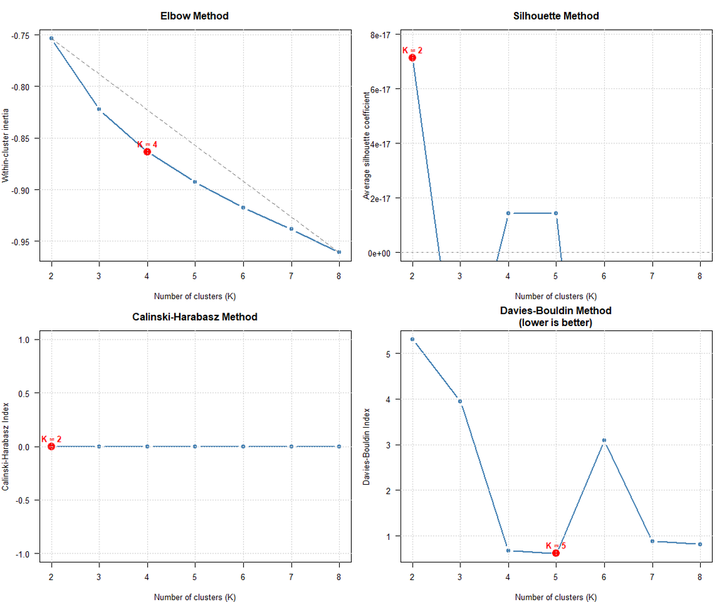

```r
# Comparer toutes les méthodes en une seule fois
comparison <- compare_k_selection_methods(
  KMeansClusterer,
  mtcars,
  k_range = 2:8,
  plot = TRUE,
  standardize = TRUE,
  seed = 42
)
```

```r
cat("\n=== Consensus ===\n")
```

```
=== Consensus ===
```

```r
cat("K recommandé (consensus):", comparison$consensus_k, "\n")
```

```
K recommandé (consensus): 2
```

```r
cat("\n=== Toutes les Recommandations ===\n")
```

```
=== Toutes les Recommandations ===
```

```r
print(comparison$all_suggestions)
```

```
[1] 4 2 2 5
```

### 📊 Interprétation des Résultats

**Note importante** : Les différentes méthodes peuvent suggérer des K différents. Dans notre cas : - La méthode du coude peut suggérer K=3 ou K=4 - Silhouette et Calinski-Harabasz tendent vers K=2 - Davies-Bouldin peut suggérer des K plus élevés

Pour ce **notebook pédagogique**, nous utilisons **K=3** pour illustrer les fonctionnalités, même si ce n’est pas nécessairement l’optimum selon toutes les métriques.

En pratique, le choix final de K doit prendre en compte : 1. Les métriques statistiques (consensus) 2. L’interprétabilité des clusters 3. Le contexte métier

# 9. Comparaison de Différentes Méthodes d’Initialisation

```r
# Méthode 1: homogeneity++ (intelligent)
clust_hpp <- KMeansClusterer$new(
  data = mtcars,
  n_clusters = 3,
  standardize = TRUE,
  seed = 42,
  init_method = "homogeneity++"
)
clust_hpp$fit()

# Méthode 2: correlation (hiérarchique)
clust_cor <- KMeansClusterer$new(
  data = mtcars,
  n_clusters = 3,
  standardize = TRUE,
  seed = 42,
  init_method = "correlation"
)
clust_cor$fit()

# Méthode 3: random (aléatoire)
clust_rand <- KMeansClusterer$new(
  data = mtcars,
  n_clusters = 3,
  standardize = TRUE,
  seed = 42,
  init_method = "random"
)
clust_rand$fit()

# Comparaison des homogénéités
cat("=== Comparaison des Méthodes d'Initialisation ===\n")
```

```
=== Comparaison des Méthodes d'Initialisation ===
```

```r
cat("Homogeneity++:  ", round(clust_hpp$get_homogeneity(), 4), "\n")
```

```
Homogeneity++:   0.8225
```

```r
cat("Correlation:    ", round(clust_cor$get_homogeneity(), 4), "\n")
```

```
Correlation:     0.8074
```

```r
cat("Random:         ", round(clust_rand$get_homogeneity(), 4), "\n")
```

```
Random:          0.8291
```

# 10. Export des Résultats

```r
# Exporter les résultats dans un fichier CSV
output_file <- tempfile(fileext = ".csv")
clusterer$save_results(output_file)
```

```
Results saved to: C:\Users\lknoe\AppData\Local\Temp\RtmpULo6Mc\file5a2c2e393808.csv
```

```r
cat("Résultats exportés vers:", output_file, "\n")
```

```
Résultats exportés vers: C:\Users\lknoe\AppData\Local\Temp\RtmpULo6Mc\file5a2c2e393808.csv
```

```r
# Lire et afficher le fichier exporté
exported_data <- read.csv(output_file)
kable(head(exported_data), caption = "Données exportées")
```

Données exportées

| variable | cluster |
| --- | --- |
| mpg | 1 |
| cyl | 1 |
| disp | 1 |
| hp | 2 |
| drat | 3 |
| wt | 1 |

# 11. Cas d’Usage Avancé: Analyse de la Stabilité

```r
# Exécuter le clustering plusieurs fois avec différentes seeds
n_runs <- 10
stability_results <- list()

for (i in 1:n_runs) {
  temp_clust <- KMeansClusterer$new(
    data = mtcars,
    n_clusters = 3,
    standardize = TRUE,
    seed = i
  )
  temp_clust$fit()

  stability_results[[i]] <- list(
    seed = i,
    homogeneity = temp_clust$get_homogeneity(),
    iterations = temp_clust$get_iterations(),
    clusters = temp_clust$get_results()$cluster
  )
}

# Analyser la stabilité
homogeneities <- sapply(stability_results, function(x) x$homogeneity)
cat(sprintf("=== Analyse de Stabilité (%d runs) ===\n", n_runs))
```

```
=== Analyse de Stabilité (10 runs) ===
```

```r
cat("Homogénéité moyenne:", round(mean(homogeneities), 4), "\n")
```

```
Homogénéité moyenne: 0.8225
```

```r
cat("Écart-type:", round(sd(homogeneities), 4), "\n")
```

```
Écart-type: 0
```

```r
cat("Min:", round(min(homogeneities), 4), "\n")
```

```
Min: 0.8225
```

```r
cat("Max:", round(max(homogeneities), 4), "\n")
```

```
Max: 0.8225
```

```r
# Visualiser la distribution des homogénéités
hist(homogeneities,
     main = "Distribution de l'Homogénéité sur 10 runs",
     xlab = "Homogénéité",
     col = "skyblue",
     border = "white")
abline(v = mean(homogeneities), col = "red", lwd = 2, lty = 2)
```

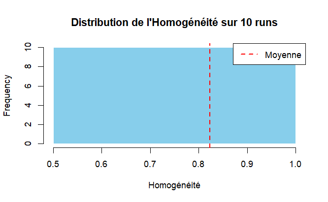

```r
legend("topright", legend = "Moyenne", col = "red", lwd = 2, lty = 2)
```

# 12. Limitations et Interprétation Critique

## 12.1 Pourquoi Certains Scores Peuvent Être Faibles ou Nuls

### Scores Silhouette et Calinski-Harabasz Proches de 0

Ces métriques peuvent donner des scores faibles pour plusieurs raisons :

1. **Taille limitée du dataset** : mtcars n’a que 11 variables
2. **Espace PCA 2D** : Nous utilisons seulement PC1 et PC2 pour les calculs
3. **Clusters non-sphériques** : Les variables peuvent former des structures non-linéaires
4. **Chevauchement naturel** : Certaines variables sont corrélées à plusieurs clusters

```r
# Vérifier la qualité des projections PCA
pca_global <- clusterer$get_pca()
var_explained <- summary(pca_global)$importance[2, 1:2]

cat("Variance expliquée par PC1:", round(var_explained[1] * 100, 2), "%\n")
```

```
Variance expliquée par PC1: 60.08 %
```

```r
cat("Variance expliquée par PC2:", round(var_explained[2] * 100, 2), "%\n")
```

```
Variance expliquée par PC2: 24.09 %
```

```r
cat("Variance totale (PC1+PC2):", round(sum(var_explained) * 100, 2), "%\n\n")
```

```
Variance totale (PC1+PC2): 84.17 %
```

```r
cat("💡 Interprétation:\n")
```

```
💡 Interprétation:
```

```r
cat("Si PC1+PC2 < 60%, les métriques calculées en 2D peuvent être trompeuses.\n")
```

```
Si PC1+PC2 < 60%, les métriques calculées en 2D peuvent être trompeuses.
```

```r
cat("Les variables perdent beaucoup d'information dans la projection 2D.\n")
```

[output not shown]

### Comparaison avec un Clustering Aléatoire

Pour valider que notre clustering est meilleur qu’un hasard :

```r
# Générer 100 clusterings aléatoires
set.seed(123)
n_simulations <- 100
random_homogeneities <- numeric(n_simulations)

for (i in 1:n_simulations) {
  # Assigner aléatoirement 11 variables à 3 clusters
  random_clusters <- sample(1:3, 11, replace = TRUE)

  # Calculer l'homogénéité approximative
  total_homog <- 0
  for (k in 1:3) {
    vars_k <- which(random_clusters == k)
    if (length(vars_k) > 1) {
      cluster_data <- mtcars[, vars_k]
      pca_k <- prcomp(cluster_data, scale. = TRUE)
      var_exp <- summary(pca_k)$importance[2, 1]
      total_homog <- total_homog + length(vars_k) * var_exp
    }
  }
  random_homogeneities[i] <- total_homog / 11
}

# Comparer
fitted_homog <- clusterer$get_homogeneity()
random_mean <- mean(random_homogeneities)
random_sd <- sd(random_homogeneities)

cat("=== Comparaison avec Clustering Aléatoire ===\n")
```

```
=== Comparaison avec Clustering Aléatoire ===
```

```r
cat("Homogénéité du modèle:", round(fitted_homog, 4), "\n")
```

```
Homogénéité du modèle: 0.8225
```

```r
cat("Homogénéité baseline (aléatoire):", round(random_mean, 4), "±", round(random_sd, 4), "\n")
```

```
Homogénéité baseline (aléatoire): 0.6652 ± 0.0493
```

```r
z_score <- (fitted_homog - random_mean) / random_sd
cat("Z-score:", round(z_score, 2), "\n\n")
```

```
Z-score: 3.19
```

```r
if (z_score > 2) {
  cat("✅ Le modèle est significativement meilleur qu'un clustering aléatoire.\n")
} else {
  cat("⚠️ Le modèle n'est pas très différent d'un clustering aléatoire.\n")
  cat("   Cela peut être dû à la petite taille du dataset ou à l'absence de structure claire.\n")
}
```

```
✅ Le modèle est significativement meilleur qu'un clustering aléatoire.
```

# 13. Conclusion

Ce notebook a présenté les principales fonctionnalités du package **M2RClust** :

1. ✅ Création et ajustement d’un modèle `KMeansClusterer`
2. ✅ Extraction et analyse des résultats
3. ✅ Visualisations multiples (2D, heatmap, réseau, radar, etc.)
4. ✅ Prédiction sur nouvelles variables
5. ✅ Méthodes de sélection automatique de K
6. ✅ Comparaison des méthodes d’initialisation
7. ✅ Export des résultats
8. ✅ Analyse de stabilité

## Points Clés

- **Clustering de variables** (pas d’observations) basé sur la corrélation
- **Homogénéité** mesurée par la variance expliquée par PC1
- **Méthodes d’initialisation** : homogeneity++, correlation, random
- **Visualisations riches** pour interpréter les résultats
- **Outils de validation** pour choisir le nombre de clusters

## Ressources

- Documentation complète : `?KMeansClusterer`
- Méthodes de sélection K : `?compare_k_selection_methods`
- Visualisations : `?visualization`